# Comparison of peptide overlap with multiple proteases

This document details investigation of combining digests from multiple proteases into a single SP3 experiment.

## Setting up the environment

I want to set a base directory that we can use as a link to the directory where we will do most of the work. I use two directories here because the Workspace is what is pushed to GitHub and contains scripts and plot files, but the Repository is where more of the big data is stored that does not get pushed.

```r
generalDatasets = 'C:/Users/chris/OneDrive/Documents/bccrc/projectsRepository/generalDatasets'
baseWorkspace = 'C:/Users/chris/OneDrive/Documents/bccrc/projectsWorkspace/sorensenLab/relatedToYbx1'
baseRepository = 'C:/Users/chris/OneDrive/Documents/bccrc/projectsRepository/sorensenLab/relatedToYbx1'
```

We need to call a source file that has some functions we will need. For simplicity and ease of tracking, I make a copy of this file in each directory that I will work in in order to be able to trace the exact one functions that are used, in case I change them and mistakenly don’t push it to GitHub.

```r
source(paste(baseWorkspace, '/design20200718_multipleProteaseSp3/userDefinedFunctions.R', sep = ''))
```

## Data processing

```r
##########################################################################################
fastaDb = readAAStringSet(paste(baseRepository, '/design20200718_multipleProteaseSp3/uniprotHumanJul2020.fasta', sep = ''))
```

So the below function aims to digest peptides based on a cleavage specificity you give it, and it works, but is mega slow. So, I deployed it on the server to run there and give me the result file. We can look at the first 100 while it runs just to serve as an optimization set.

```r
##########################################################################################
outputData = data.frame()
for (i in 1:100){
  inputSequence = as.character(fastaDb[[i]])
  digestData = enzymeCoverage(inputSequence, 'KR', i)
  outputData = rbind(outputData, digestData)
  print(paste(i,'proteins completed'))
}
```

```
[1] "No peptides at cut site R."
[1] "1 proteins completed"
[1] "2 proteins completed"
[1] "No peptides at cut site K."
[1] "3 proteins completed"
[1] "4 proteins completed"
[1] "No peptides at cut site K."
[1] "5 proteins completed"
[1] "6 proteins completed"
[1] "7 proteins completed"
[1] "8 proteins completed"
[1] "9 proteins completed"
[1] "10 proteins completed"
[1] "No peptides at cut site K."
[1] "11 proteins completed"
```

[output cut: 96 more lines]

Make a plot with this test set that we can use to optimize the plot code for our big set.

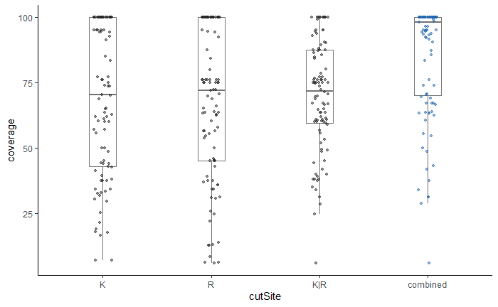

```r
##########################################################################################
combinedData = unique(dplyr::select(outputData, seqnames, combinedCoverage))
combinedData$cutSite = 'combined'
colnames(combinedData)[2] = 'coverage'
outputDataPlot = rbind(outputData[,c(1:3)], combinedData)
outputDataPlot$cutSite = factor(outputDataPlot$cutSite, levels = c('K','R','K|R','combined'))
##
ggplot(outputDataPlot, aes(cutSite, coverage, color = cutSite)) +
  geom_boxplot(size = 0.5, width = 0.25, color = brewer.pal(8,'Greys')[6], outlier.shape = NA) +
  geom_point(size = 1, position = position_jitterdodge(jitter.width = 0.5), alpha = 0.5) +
  scale_color_manual(values = c(rep(brewer.pal(8,'Greys')[8],3), brewer.pal(8,'RdBu')[8])) +
  theme_classic() +
  theme(legend.position = 'none')
ggsave(paste(baseRepository, '/design20200718_multipleProteaseSp3/boxplot_krCutSiteCoverageMap.pdf', sep = ''),
       height = 4, width = 4, useDingbats = FALSE)
```

Now make a plot for the fully processed set.

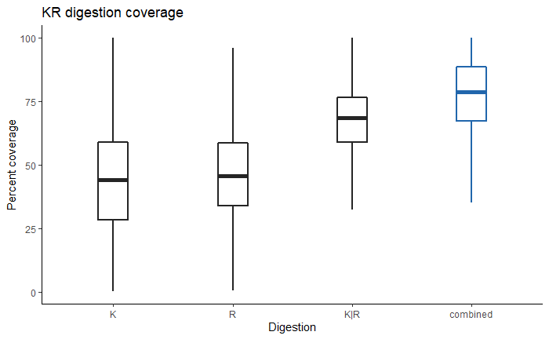

```r
##########################################################################################
outputData = readRDS(paste(baseRepository, '/design20200718_multipleProteaseSp3/uniprotHumanJul2020Digested.rds', sep = ''))
combinedData = unique(dplyr::select(outputData, seqnames, combinedCoverage))
combinedData$cutSite = 'combined'
colnames(combinedData)[2] = 'coverage'
outputDataPlot = rbind(outputData[,c(1:3)], combinedData)
outputDataPlot$cutSite = factor(outputDataPlot$cutSite, levels = c('K','R','K|R','combined'))
##
ggplot(outputDataPlot, aes(cutSite, coverage, color = cutSite)) +
  geom_boxplot(size = 1, width = 0.25, outlier.shape = NA) +
  #geom_point(size = 1, position = position_jitterdodge(jitter.width = 0.5), alpha = 0.5) +
  scale_color_manual(values = c(rep(brewer.pal(8,'Greys')[8],3), brewer.pal(8,'RdBu')[8])) +
  labs(x = 'Digestion', y = 'Percent coverage', title = 'KR digestion coverage') +
  theme_classic() +
  theme(legend.position = 'none')
ggsave(paste(baseRepository, '/design20200718_multipleProteaseSp3/boxplot_krCutSiteCoverageMap.pdf', sep = ''),
       height = 4, width = 4, useDingbats = FALSE)
```

[session information not shown]